DS 6030 | Fall 2024 | University of Virginia

# Homework #4: Trees and Random Forest

Author

**Ainsley McLaughlin**

Published

October 1, 2024

This is an **independent assignment**. Do not discuss or work with classmates.

# Required R packages and Directories

```r
data_dir = 'https://mdporter.github.io/teaching/data/' # data directory
library(tidyverse)    # functions for data manipulation
library(ranger)       # fast random forest implementation
library(modeldata)    # for the ames housing data
```

# Problem 1: Tree splitting metrics for classification

Consider the Gini index, classification error, and entropy impurity measures in a simple classification setting with two classes.

Create a single plot that displays each of these quantities as a function of $p_m$, the estimated probability of an observation in node $m$ being from class 1. The x-axis should display $p_m$, ranging from 0 to 1, and the y-axis should display the value of the Gini index, classification error, and entropy.

Personal Notes: - Misclassification Error: This measures the proportion of observations that do not belong to the majority class in region Rm. It is minimized when all observations in a node belong to the same class - The Gini Index measures the likelihood of misclassifying a randomly chosen observation from the node. It is 0 when all observations in a node belong to the same class and reaches its maximum when class probabilities are uniform - Cross-Entropy/Deviance: This measures the amount of uncertainty in the node. It is minimized when one class probability is 1 (i.e., full certainty about class membership) and is maximized when class probabilities are evenly distributed. It is proportional to the negative of the multinomial log-likelihood (and hence deviance)

**Solution**

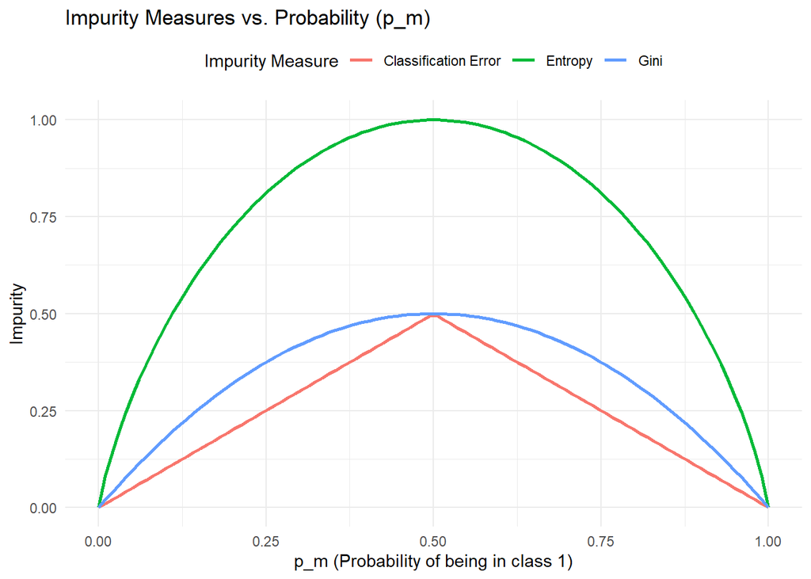

```r
# Load necessary library
library(ggplot2)

# Define a sequence of p_m values ranging from 0 to 1
p_m <- seq(0, 1, length.out = 100)

# Calculate the Gini index, classification error, and entropy
gini <- 2 * p_m * (1 - p_m)
classification_error <- 1 - pmax(p_m, 1 - p_m)
entropy <- -p_m * log2(p_m) - (1 - p_m) * log2(1 - p_m)

# Handle cases where p_m is 0 or 1 to avoid NaN values in entropy
entropy[is.na(entropy)] <- 0

# Create a data frame for plotting
impurity_data <- data.frame(
  p_m = rep(p_m, 3),
  impurity = c(gini, classification_error, entropy),
  measure = factor(rep(c("Gini", "Classification Error", "Entropy"), each = 100))
)

# Plot using ggplot2
ggplot(impurity_data, aes(x = p_m, y = impurity, color = measure)) +
  geom_line(size = 1) +
  labs(
    title = "Impurity Measures vs. Probability (p_m)",
    x = "p_m (Probability of being in class 1)",
    y = "Impurity",
    color = "Impurity Measure"
  ) +
  theme_minimal() +
  theme(legend.position = "top")
```

# Problem 2: Combining bootstrap estimates

Suppose we produce ten bootstrapped samples from a data set containing red and green classes. We then apply a classification tree to each bootstrapped sample and, for a specific value of $X$, produce the following 10 estimates of $\Pr(\text{Class is Red} \mid X=x)$: $\{0.2, 0.25, 0.3, 0.4, 0.4, 0.45, 0.7, 0.85, 0.9, 0.9\}$.

## a. Majority Vote

ISLR 8.2 describes the *majority vote* approach for making a hard classification from a set of bagged classifiers. What is the final classification for this example using majority voting?

Notes: . For a given test observation, we can record the class predicted by each of the B trees, and take a majority vote: the overall prediction is the most commonly occurring majority vote class among the B predictions.

**Solution**

```r
p_red <- c(0.2, 0.25, 0.3, 0.4, 0.4, 0.45, 0.7, 0.85, 0.9, 0.9)
class_r_g <- c()  # Initialize an empty vector for the classifications

#loop thru p_red and classify as red or green for each prob
for (i in seq_along(p_red)) {
  if (p_red[i] >= 0.5) {
    class_r_g[i] <- "r"  # If probability >= 0.5, red
  } else {
    class_r_g[i] <- "g"  # If probability < 0.5, green
  }
}

#most frequent class (majority vote)
classification_r_g <- names(which.max(table(class_r_g)))

# Output it
if (classification_r_g == "g") {
  print("The classification is green")
} else {
  print("The classification is red")
}
```

```
[1] "The classification is green"
```

## b. Average Probability

An alternative is to base the final classification on the average probability. What is the final classification for this example using average probability?

**Solution**

```r
# Calculate the average probability
avg_pred <- mean(p_red)

# Classify based on the average probability
if (avg_pred >= 0.5) {
  print("The class is red")
} else {
  print("The class is green")
}
```

```
[1] "The class is red"
```

# Problem 3: Random Forest Tuning

Random forest has several tuning parameters that you will explore in this problem. We will use the `ames` housing data from the `modeldata` R package.

There are several R packages for Random Forest. The `ranger::ranger()` function is much faster than `randomForest::randomForest()` so we will use this one.

## a. Random forest (`ranger`) tuning parameters

List all of the random forest tuning parameters in the `ranger::ranger()` function. You don’t need to list the parameters related to computation, special models (e.g., survival, maxstat), or anything that won’t impact the predictive performance.

Indicate the tuning parameters you think will be most important to optimize?

**Solution**

```r
#help(ranger) # brings up the R documentation on this
```

The parameters for the ranger :: range() function are:ranger( formula = NULL, data = NULL, num.trees = 500, mtry = NULL, importance = “none”, write.forest = TRUE, probability = FALSE, min.node.size = NULL, min.bucket = NULL, max.depth = NULL, replace = TRUE, sample.fraction = ifelse(replace, 1, 0.632), case.weights = NULL, class.weights = NULL, splitrule = NULL, num.random.splits = 1, alpha = 0.5, minprop = 0.1, split.select.weights = NULL, always.split.variables = NULL, respect.unordered.factors = NULL, scale.permutation.importance = FALSE, local.importance = FALSE, regularization.factor = 1, regularization.usedepth = FALSE, keep.inbag = FALSE, inbag = NULL, holdout = FALSE, quantreg = FALSE, time.interest = NULL, oob.error = TRUE, num.threads = NULL, save.memory = FALSE, verbose = TRUE, node.stats = FALSE, seed = NULL, dependent.variable.name = NULL, status.variable.name = NULL, classification = NULL, x = NULL, y = NULL, … )

The important parameters to optimize will likely be: num.trees, mtry, importance, min.node.size, min.bucket, max.depth, sample.fraction, class.weights?, num.random.splits, num.threads?, save.memory?,

## b. Implement Random Forest

Use a random forest model to predict the sales price, `Sale_Price`. Use the default parameters and report the 10-fold cross-validation RMSE (square root of mean squared error).

**Solution**

[output not shown]

## c. Random Forest Tuning

Now we will vary the tuning parameters of `mtry` and `min.bucket` to see what effect they have on performance.

- Use a range of reasonable `mtry` and `min.bucket` values.
  - The valid `mtry` values are $\{1,2, \ldots, p\}$ where $p$ is the number of predictor variables. However the default value of `mtry = sqrt(p) =` 8 is usually close to optimal, so you may want to focus your search around those values.
  - The default `min.bucket=1` will grow deep trees. This will usually work best if there are enough trees. But try some values larger and see how it impacts predictive performance.
  - Set `num.trees=1000`, which is larger than the default of 500.
- Use 5 times repeated out-of-bag (OOB) to assess performance. That is, run random forest 5 times for each tuning set, calculate the OOB MSE each time and use the average for the MSE associated with the tuning parameters.
- Use a single plot to show the average MSE as a function of `mtry` and `min.bucket`.
- Report the best tuning parameter combination.
- Note: random forest is a stochastic model; it will be different every time it runs due to the bootstrap sampling and random selection of features to consider for splitting. Set the random seed to control the uncertainty associated with the stochasticity.
- Hint: If you use the `ranger` package, the `prediction.error` element in the output is the OOB MSE.

**Solution**